# Prediction Assignment Writeup

Subha

22/09/2020

```r
knitr::opts_chunk$set(echo = TRUE)
```

## Synopsis

The goal is to predict the manner in which they did the exercise. This is the “classe” variable in the training set. I will create a report describing how I have built my model, how I have used cross validation, what I think the expected out of sample error is, and why I have made the choices I did. I will also use your prediction model to predict 20 different test cases.

## Data Description

The training data for this project are available here:

https://d396qusza40orc.cloudfront.net/predmachlearn/pml-training.csv

The test data are available here:

https://d396qusza40orc.cloudfront.net/predmachlearn/pml-testing.csv

The data for this project come from this source: http://web.archive.org/web/20161224072740/http:/groupware.les.inf.puc-rio.br/har.

## Loading the dataset and libraries

```r
suppressPackageStartupMessages({library(dplyr)
library(ggplot2)
library(caret)
library(knitr)
library(plotly)
library(randomForest)
library(gbm)
library(rpart)
library(rpart.plot)
library(rattle)})

train_url <- "http://d396qusza40orc.cloudfront.net/predmachlearn/pml-training.csv"
test_url  <- "http://d396qusza40orc.cloudfront.net/predmachlearn/pml-testing.csv"

init_org_training_data <- read.csv(url(train_url))
init_org_testing_data <- read.csv(url(test_url))

dim(init_org_training_data)
```

```
## [1] 19622   160
```

```r
dim(init_org_testing_data)
```

```
## [1]  20 160
```

## Data Cleansing

```r
###Removing Variables which are having Nearly Zero Variance.
nzv <- nearZeroVar(init_org_training_data)

train_data <- init_org_training_data[,-nzv]
test_data <- init_org_testing_data[,-nzv]

###Removing NA Values of Variables.
na_val_col <- sapply(train_data, function(x) mean(is.na(x))) > 0.95
train_data <- train_data[,na_val_col == FALSE]
test_data <- test_data[,na_val_col == FALSE]

###Removing the first 7 Variables which are Non-Numeric.
train_data<- train_data[, 8:59]
test_data<- test_data[, 8:59]

dim(train_data)
```

```
## [1] 19622    52
```

```r
dim(test_data)
```

```
## [1] 20 52
```

## Data Partioning

Following the recommendation in the course Practical Machine Learning, we will split our data into a training data set (60% of the total cases) and a testing data set (40% of the total cases; the latter should not be confused with the data in the pml-testing.csv file). This will allow us to estimate the out of sample error of our predictor.

```r
inTrain<- createDataPartition(train_data$classe, p=0.6, list=FALSE)
training<- train_data[inTrain,]
testing<- train_data[-inTrain,]

dim(training)
```

```
## [1] 11776    52
```

```r
dim(testing)
```

```
## [1] 7846   52
```

## Decision Tree Model

Using Decision Tree, we shouldn’t expect the accuracy to be high. In fact, anything around 80% would be acceptable.

```r
DT_model<- train(classe ~. , data=training, method= "rpart")
DT_prediction<- predict(DT_model, testing)
confusionMatrix(DT_prediction, as.factor(testing$classe))
```

```
## Confusion Matrix and Statistics
##
##           Reference
## Prediction    A    B    C    D    E
##          A 1590  387   68  169   96
##          B   22  566   42   30  187
##          C  422  263 1128  366  404
##          D  159  173   36  660  130
##          E   39  129   94   61  625
##
## Overall Statistics
##
##                Accuracy : 0.5823
##                  95% CI : (0.5713, 0.5933)
##     No Information Rate : 0.2845
##     P-Value [Acc > NIR] : < 2.2e-16
##
##                   Kappa : 0.4724
##
##  Mcnemar's Test P-Value : < 2.2e-16
##
## Statistics by Class:
##
##                      Class: A Class: B Class: C Class: D Class: E
## Sensitivity            0.7124  0.37286   0.8246  0.51322  0.43343
## Specificity            0.8717  0.95559   0.7754  0.92409  0.94956
## Pos Pred Value         0.6883  0.66824   0.4367  0.56995  0.65928
## Neg Pred Value         0.8840  0.86398   0.9544  0.90640  0.88156
## Prevalence             0.2845  0.19347   0.1744  0.16391  0.18379
## Detection Rate         0.2027  0.07214   0.1438  0.08412  0.07966
## Detection Prevalence   0.2944  0.10795   0.3292  0.14759  0.12083
## Balanced Accuracy      0.7921  0.66423   0.8000  0.71865  0.69149
```

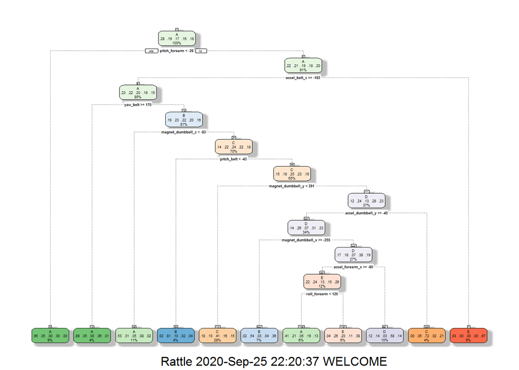

```r
fancyRpartPlot(DT_model$finalModel)
```

```r
###Fit the model
RF_model<- train(classe ~. , data=training, method= "rf", ntree=100)
###Prediction
RF_prediction<- predict(RF_model, testing)
RF_cm<-confusionMatrix(RF_prediction, as.factor(testing$classe))
RF_cm
```

```
## Confusion Matrix and Statistics
##
##           Reference
## Prediction    A    B    C    D    E
##          A 2227   17    0    0    0
##          B    4 1494   10    0    2
##          C    1    5 1357   17    3
##          D    0    0    1 1268    4
##          E    0    2    0    1 1433
##
## Overall Statistics
##
##                Accuracy : 0.9915
##                  95% CI : (0.9892, 0.9934)
##     No Information Rate : 0.2845
##     P-Value [Acc > NIR] : < 2.2e-16
##
##                   Kappa : 0.9892
##
##  Mcnemar's Test P-Value : NA
##
## Statistics by Class:
##
##                      Class: A Class: B Class: C Class: D Class: E
## Sensitivity            0.9978   0.9842   0.9920   0.9860   0.9938
## Specificity            0.9970   0.9975   0.9960   0.9992   0.9995
## Pos Pred Value         0.9924   0.9894   0.9812   0.9961   0.9979
## Neg Pred Value         0.9991   0.9962   0.9983   0.9973   0.9986
## Prevalence             0.2845   0.1935   0.1744   0.1639   0.1838
## Detection Rate         0.2838   0.1904   0.1730   0.1616   0.1826
## Detection Prevalence   0.2860   0.1925   0.1763   0.1622   0.1830
## Balanced Accuracy      0.9974   0.9908   0.9940   0.9926   0.9966
```

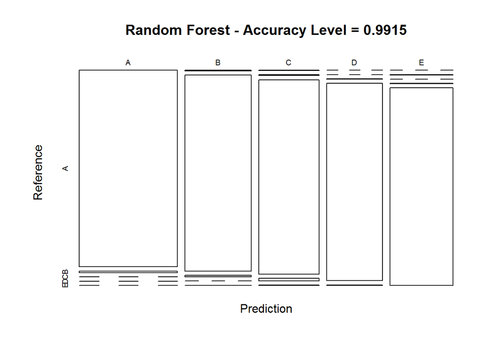

```r
plot(RF_cm$table, col = RF_cm$byClass,
     main = paste("Random Forest - Accuracy Level =",
                  round(RF_cm$overall['Accuracy'], 4)))
```

From the Confusion Matrix, we can clearly see that the prediction accuracy of Random Forest model is 99% which is satisfactory.

## Final Prediction- Applying selected model on the Test Data

```r
Final_RF_prediction <- predict(RF_model, test_data )
Final_RF_prediction
```

```
##  [1] B A B A A E D B A A B C B A E E A B B B
## Levels: A B C D E
```